# Deep Learning the Phase Transition: A CNN Approach to the 2D Ising Model

NING Siyuan

October 11, 2023

**It has been proven that Monte Carlo methods combined with Machine Learning can be used to identify phase transitions in physical systems [1].** The project will start by quickly simulating the Ising model using the Monte Carlo method to obtain representative sets of spin configurations for a bunch of temperatures. Afterwards, the traditional approach of inspecting the magnetization, the order parameter of the transition, and its susceptibility is not taken. Instead, supervised learning is used to train a simple Neural Network to automagically learn the transition temperature.

**Reference:**  
[1] Carrasquilla, J., Melko, R. Machine learning phases of matter. Nature Phys 13, 431–434 (2017). https://doi.org/10.1038/nphys4035  
[2] https://juliaphysics.github.io/PhysicsTutorials.jl/tutorials/machine_learning/ml_ising/ml_ising.html  
[3] https://github.com/owenpb/IsingTransition  
[4] https://warwick.ac.uk/fac/sci/physics/staff/academic/roemer/publications/Thesis_Civitcioglu_2020.pdf

# Ising model simulation: Classical Monte Carlo

## Metropolis Approach to the Ising Model

The Ising model serves as a quintessential lattice model for examining magnetic behavior. This exploration focuses on a square lattice (subject to periodic boundary conditions) encompassing $N = L \times L$ sites, where each site hosts an Ising spin $S=\pm 1$. Restricting attention to nearest-neighbor interactions, the aggregate energy is denoted by:

$$ E = J \sum_{\langle i, j \rangle} S_i S_j, $$

where the summation extends over all adjacent site pairs. Herein, $J$ represents the Ising coupling with $J=+1$ signifying an antiferromagnetic interaction, and $J=-1$ indicating a ferromagnetic coupling. This narrative delves into the antiferromagnetic scenario, scrutinizing the phase transition from a high-temperature disordered state to a low-temperature checkerboard pattern.

On flipping a spin at site $(x, y)$, the energy alteration $\Delta E$ between the new and former configurations is expressed as:

$$ J( [S^{new}_{x,y} S_{x+1, y} + S^{new}_{x,y}S_{x-1, y} + S^{new}_{x,y}S_{x,y+1} + S^{new}_{x,y}S_{x,y-1}] - [S^{old}_{x,y} S_{x+1, y} + S^{old}_{x,y}S_{x-1, y} + S^{old}_{x,y}S_{x,y+1} + S^{old}_{x,y}S_{x,y-1}]) $$

Simplifying, we obtain:

$$ \Delta E = J (S^{new}_{x,y} - S^{old}_{x,y}) [S_{x+1, y} + S_{x-1, y} + S_{x,y+1} + S_{x,y-1}] $$

The selected spin for flipping, $S^{old}_{x,y}$, is either $1$ or $-1$.

For $S^{old}_{x,y} = 1$, the proposed update renders $S^{new}_{xy} = -1$, yielding $S^{new}_{x,y} - S^{old}_{x,y} = -2$.

For $S^{old}_{x,y} = -1$, the update results in $S^{new}_{xy} = 1$, thus $S^{new}_{x,y} - S^{old}_{x,y} = 2$.

Thus, the energy shift can be universally articulated as:

$$ \Delta E = -2J(S^{old}_{x,y}) [S_{x+1, y} + S_{x-1, y} + S_{x,y+1} + S_{x,y-1}] $$

For any spin configuration $m$ with associated energy $E_m$, the state probability is $P_m = \frac{1}{Z} e^{-\beta E_m}$, where $Z = \sum_m e^{-\beta E_m}$ denotes the partition function. The Monte Carlo technique proposed herein entails random spin flips within the lattice, adjudicating acceptance or rejection based on the Metropolis-Hastings criterion. Specifically, each Monte Carlo iteration proposes a spin flip, transitioning from configuration $m$ to $n$. This move is approved if $E_n \leq E_m$, or else accepted with a probability of $e^{(-\beta \Delta E)}$.

```python
import numpy as np
import pandas as pd
import random
import matplotlib.pyplot as plt
```

## Key Algorithm Steps in Metropoli Sampling

### Binning Process

In the `simulation` function, the binning process is initiated by defining empty arrays `mag_binned` and `stag_mag_binned` to store the binned values of magnetization and staggered magnetization respectively. During the measurement sweeps, which are nested within the binning loop (`for n in range(N_bin):`), the magnetization (`mag`) and staggered magnetization (`stag_mag`) are calculated and accumulated into the current bin, using the lines `mag_binned[n] += mag` and `stag_mag_binned[n] += np.abs(stag_mag)`. The significance of the binning process lies in its ability to reduce autocorrelations among the measurements, which is typical in Monte Carlo simulations. By grouping measurements into bins and averaging them (`mag_binned[n] /= bin_size` and `stag_mag_binned[n] /= bin_size`), the data becomes less correlated, which in turn provides more accurate estimates of statistical errors and better reflects the true statistical properties of the system.

### Warm-up Phase

The warm-up phase commences with a specified number of warm-up sweeps controlled by the variables `N_warm` or `N_warm_2`, depending on the temperature. During each warm-up sweep, a site on the lattice is randomly selected (`x = random.randrange(L)`, `y = random.randrange(L)`) and a trial spin flip is attempted following the Metropolis algorithm criteria, as illustrated in the lines: `if DeltaE < 0: spins[x][y] = -1 * S_old` and `elif random.random() < np.exp(-1 * beta * DeltaE): spins[x][y] = -1 * S_old`. The warm-up phase is critical for transitioning the system from an arbitrary initial configuration to a thermally equilibrated state, which is imperative for the accurate measurement of system properties. This phase ensures that the subsequent measurements are representative of the equilibrium state of the system at the given temperature.

### Switching Scan Numbers Near Critical Values

Within the `simulation` function, a mechanism is implemented to switch the number of warm-up and measurement sweeps in a specific temperature range (`T2_min` to `T2_max`). This is achieved with the lines: `if T2_min <= T <= T2_max: Num_warm = N_warm_2` and `Num_meas = N_meas_2`, which alter the sweep numbers to `N_warm_2` and `N_meas_2` respectively if the temperature `T` falls within this critical range. The ability to adjust the number of sweeps near critical temperatures is essential for capturing the more complex behavior of the system in this region. By increasing the sweep numbers, more data is collected which yields a more precise characterization of the phase transition, thereby enhancing the reliability and resolution of the simulation outcomes in the critical region.

### Visualization of Spin Configurations

A visual representation of the spin configurations is generated at five equally spaced temperatures between `T_min` and `T_max`. Three subplots are created for each temperature, showing the initial random configuration, the configuration post-warmup, and the configuration post-measurement on a 12x12 grid, where each cell represents the spin state of a lattice site. This visualization aids in understanding the evolution of the system's state throughout the simulation process at different temperatures.

```python
def simulation(J, L, T_min, T_max, N_temps, N_bin, N_warm, N_meas, T2_min, T2_max, N_warm_2, N_meas_2):


    T_array = np.linspace(T_min, T_max, N_temps)

    # Initialize arrays to store final magnetization M, staggered magnetization, and their errors, for each temperature:
    m_array = np.zeros(N_temps)
    sm_array = np.zeros(N_temps)
    me_array = np.zeros(N_temps)
    sme_array = np.zeros(N_temps)

    binned_configurations_array = np.zeros(shape=((N_temps*N_bin), ((L*L)+1)))

    # Define an array of alternating 1 and -1 entries used for calculating staggered magnetization:
    alternating = np.zeros((L, L))
    for i in range(L):
        for j in range(L):
            alternating[i][j] = ((-1)**(i+j))

    # Sweep through each temperature:
    for t in range(N_temps):

        T = T_array[t]

        beta = 1 / T   # Inverse temperature

        # Initialize lattice with randomized spin configuration:
        spins = np.zeros(shape=(L, L), dtype=int)
        for x in range(L):
            for y in range(L):
                spins[x][y] = random.choice([1,-1])

        initial_spins = np.copy(spins)


        # Set additional sweeps near critical temperature:
        if T2_min <= T <= T2_max:
            Num_warm = N_warm_2
            Num_meas = N_meas_2
        else:
            Num_warm = N_warm
            Num_meas = N_meas

        bin_size = int(Num_meas/N_bin)

        mag_binned = np.zeros(N_bin)
        stag_mag_binned = np.zeros(N_bin)


        # Perform Num_warm warm-up sweeps:
        for i in range(Num_warm):

            x = random.randrange(L)
            y = random.randrange(L)

            S_old = spins[x][y]

            DeltaE = -2 * J * S_old * (spins[(x+1)%L][y] + spins[(x-1)%L][y] + spins[x][(y+1)%L] + spins[x][(y-1)%L])

            if DeltaE < 0:

                spins[x][y] = -1 * S_old

            elif random.random() < np.exp(-1 * beta * DeltaE):

                spins[x][y] = -1 * S_old

        warmed_spins = np.copy(spins)


        # Perform Num_meas measurement sweeps:
        for n in range(N_bin):

            for m in range(bin_size):

                x = random.randrange(L)
                y = random.randrange(L)

                S_old = spins[x][y]

                DeltaE = -2 * J * S_old * (spins[(x+1)%L][y] + spins[(x-1)%L][y] + spins[x][(y+1)%L] + spins[x][(y-1)%L])

                if DeltaE < 0:

                    spins[x][y] = -1 * S_old

                elif random.random() < np.exp(-1 * beta * DeltaE):

                    spins[x][y] = -1 * S_old

                stag_mag = (np.sum(alternating * spins) / (L*L))
                mag = np.sum(spins) / (L*L)

                mag_binned[n] += mag
                stag_mag_binned[n] += np.abs(stag_mag)


            bin_config = spins.flatten()
            bin_config = np.append(bin_config, T)
            binned_configurations_array[(t * N_bin) + n] = bin_config


            mag_binned[n] /= bin_size
            stag_mag_binned[n] /= bin_size


        measured_spins = np.copy(spins)


        # Calculate average of binned measurements and standard error of the mean:
        mag_avg = np.mean(mag_binned)
        mag_error = np.std(mag_binned, ddof=1) / np.sqrt(N_bin)

        stag_mag_avg = np.mean(stag_mag_binned)
        stag_mag_error = np.std(stag_mag_binned, ddof=1) / np.sqrt(N_bin)

        # Append measurements for this temperature T to arrays:
        m_array[t] = mag_avg
        me_array[t] = mag_error
        sm_array[t] = stag_mag_avg
        sme_array[t] = stag_mag_error

        if T in np.linspace(T_min, T_max, 5):

            print('####################')
            print(f'##### T = {T:.2f} #####')
            print('####################')

            # Display the intial, post-warmup, and post-measurement spin configurations:
            fig, axs = plt.subplots(1, 3, figsize=(12, 3))
            axs[0].set_xticks(ticks=range(L))
            axs[0].set_yticks(ticks=range(L))
            axs[0].imshow(initial_spins, origin='lower', cmap='binary')
            axs[0].set_title('Initial random configuration', fontsize=10)
            axs[1].set_xticks(ticks=range(L))
            axs[1].set_yticks(ticks=range(L))
            axs[1].imshow(warmed_spins, origin='lower', cmap='binary')
            axs[1].set_title('Configuration after warmup', fontsize=10)
            axs[2].set_xticks(ticks=range(L))
            axs[2].set_yticks(ticks=range(L))
            axs[2].imshow(measured_spins, origin='lower', cmap='binary')
            axs[2].set_title('Configuration after measurements', fontsize=10)
            plt.show()

            # Print measurement statistics:
            print(f'T = {T:.2f} statistics: ')
            print(f'mag_avg = {mag_avg:.6g}')
            print(f'mag_error = {mag_error:.6g}')
            print(f'stag_mag_avg = {stag_mag_avg:.6g}')
            print(f'stag_mag_error = {stag_mag_error:.6g}')
            print('\n\n\n\n\n')

    return binned_configurations_array, T_array, m_array, me_array, sm_array, sme_array
```

```
####################
##### T = 1.00 #####
####################
```

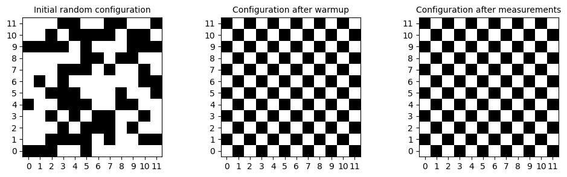

```
T = 1.00 statistics:
mag_avg = -0.000175278
mag_error = 0.000152873
stag_mag_avg = 0.999072
stag_mag_error = 0.000197052






####################
##### T = 2.00 #####
####################
```

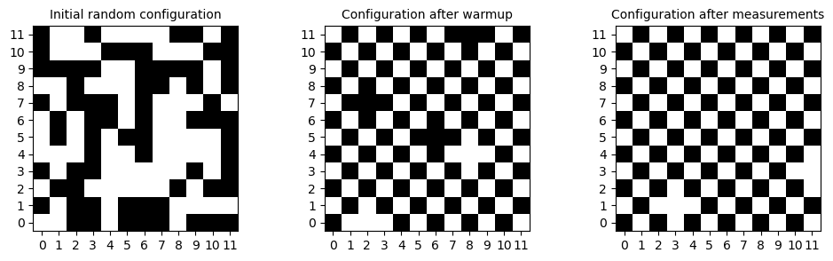

```
T = 2.00 statistics:
mag_avg = 0.000536285
mag_error = 0.000539317
stag_mag_avg = 0.910794
stag_mag_error = 0.00336222






####################
##### T = 3.00 #####
####################
```

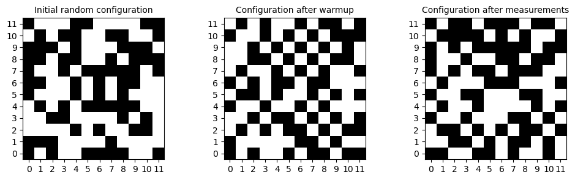

```
T = 3.00 statistics:
mag_avg = -0.000560868
mag_error = 0.000696737
stag_mag_avg = 0.230762
stag_mag_error = 0.00759192






####################
##### T = 4.00 #####
####################
```

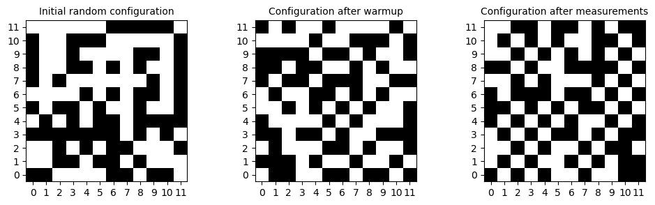

```
T = 4.00 statistics:
mag_avg = 0.000767361
mag_error = 0.00170793
stag_mag_avg = 0.139566
stag_mag_error = 0.00642814






####################
##### T = 5.00 #####
####################
```

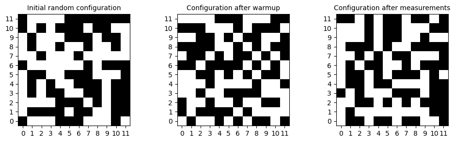

```
T = 5.00 statistics:
mag_avg = -0.000225417
mag_error = 0.00179614
stag_mag_avg = 0.109042
stag_mag_error = 0.00364818
```

```python
J = 1
L = 12
T_min = 1
T_max = 5
N_temps = 41
N_bin = 100
N_warm = 100000
N_meas = 100000
T2_min = 2
T2_max = 3
N_warm_2 = 400000
N_meas_2 = 400000

Isingdata, T_array, m_array, me_array, sm_array, sme_array = simulation(J, L, T_min, T_max, N_temps, N_bin, N_warm, N_meas, T2_min, T2_max, N_warm_2, N_meas_2)
```

## View the Generated Ising Dataset

```python
Isingdata.shape
```

```
(4100, 145)
```

```python
Isingdata_df = pd.DataFrame(Isingdata)
Isingata_df.rename({144:'Temperature'}, axis=1, inplace=True)
Isingata_df.tail(10)
```

|  | 0 | 1 | 2 | 3 | 4 | 5 | 6 | 7 | 8 | 9 | ... | 135 | 136 | 137 | 138 | 139 | 140 | 141 | 142 | 143 | Temperature |
| --- | --- | --- | --- | --- | --- | --- | --- | --- | --- | --- | --- | --- | --- | --- | --- | --- | --- | --- | --- | --- | --- |
| 4090 | -1.0 | -1.0 | 1.0 | -1.0 | -1.0 | -1.0 | 1.0 | 1.0 | 1.0 | 1.0 | ... | -1.0 | 1.0 | 1.0 | 1.0 | 1.0 | -1.0 | 1.0 | 1.0 | -1.0 | 5.0 |
| 4091 | -1.0 | 1.0 | -1.0 | -1.0 | -1.0 | 1.0 | -1.0 | -1.0 | 1.0 | 1.0 | ... | 1.0 | 1.0 | -1.0 | -1.0 | -1.0 | 1.0 | -1.0 | 1.0 | 1.0 | 5.0 |
| 4092 | 1.0 | -1.0 | -1.0 | -1.0 | 1.0 | 1.0 | -1.0 | 1.0 | -1.0 | 1.0 | ... | -1.0 | -1.0 | 1.0 | 1.0 | -1.0 | 1.0 | -1.0 | 1.0 | -1.0 | 5.0 |
| 4093 | 1.0 | -1.0 | 1.0 | -1.0 | -1.0 | 1.0 | 1.0 | -1.0 | -1.0 | 1.0 | ... | 1.0 | 1.0 | -1.0 | 1.0 | 1.0 | -1.0 | -1.0 | -1.0 | -1.0 | 5.0 |
| 4094 | 1.0 | 1.0 | -1.0 | -1.0 | 1.0 | -1.0 | 1.0 | -1.0 | -1.0 | -1.0 | ... | 1.0 | -1.0 | 1.0 | 1.0 | 1.0 | 1.0 | 1.0 | -1.0 | 1.0 | 5.0 |
| 4095 | -1.0 | -1.0 | 1.0 | -1.0 | -1.0 | 1.0 | -1.0 | -1.0 | -1.0 | -1.0 | ... | 1.0 | 1.0 | 1.0 | -1.0 | 1.0 | -1.0 | 1.0 | 1.0 | 1.0 | 5.0 |
| 4096 | 1.0 | 1.0 | -1.0 | 1.0 | -1.0 | -1.0 | -1.0 | 1.0 | -1.0 | 1.0 | ... | -1.0 | 1.0 | -1.0 | 1.0 | 1.0 | -1.0 | 1.0 | -1.0 | 1.0 | 5.0 |
| 4097 | 1.0 | -1.0 | -1.0 | 1.0 | -1.0 | 1.0 | -1.0 | 1.0 | 1.0 | 1.0 | ... | -1.0 | 1.0 | 1.0 | 1.0 | -1.0 | 1.0 | -1.0 | -1.0 | -1.0 | 5.0 |
| 4098 | 1.0 | -1.0 | 1.0 | 1.0 | -1.0 | 1.0 | -1.0 | 1.0 | -1.0 | -1.0 | ... | -1.0 | 1.0 | -1.0 | 1.0 | -1.0 | 1.0 | -1.0 | -1.0 | -1.0 | 5.0 |
| 4099 | -1.0 | 1.0 | 1.0 | -1.0 | 1.0 | 1.0 | -1.0 | 1.0 | 1.0 | -1.0 | ... | 1.0 | -1.0 | 1.0 | 1.0 | -1.0 | 1.0 | 1.0 | -1.0 | 1.0 | 5.0 |

10 rows × 145 columns

## Staggered Magnetization vs $T/J$

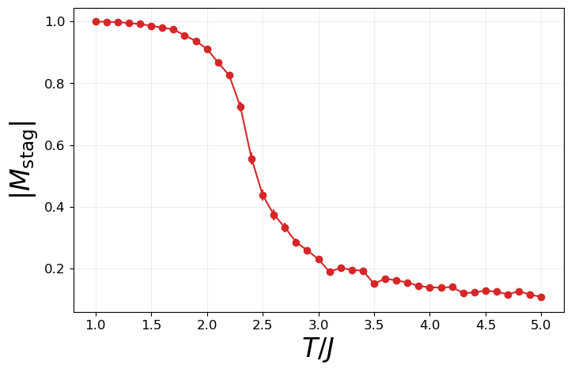

```python
plt.figure(figsize=(8,5))
plt.errorbar(T_array, sm_array, yerr=sme_array, marker='o', linestyle='solid', color='tab:red')
plt.ylabel(r'$|M_{\mathrm{stag}}|$', fontsize=24)
plt.yticks(fontsize=12)
plt.xlabel(r'$T/J$', fontsize=24)
plt.xticks(fontsize=12)
plt.grid(alpha=0.2)
plt.show()
```

## Save data as .csv for CNN training

```python
np.savetxt('Isingdata.csv', Isingdata, delimiter=',')
```

# Critical Temperature Estimate: CNN

```python
import numpy as np
import matplotlib.pyplot as plt

from sklearn.model_selection import train_test_split

import torch
import torchvision
import torch.nn as nn
from torch.utils.data import DataLoader, TensorDataset
```

## Load data

```python
data = np.loadtxt('Isingdata.csv', delimiter=',')
```

```python
X = data[:, :-1]
T = data[:, -1]
```

```python
X.shape  # 41 temperatures, 100 samples each. 12x12 lattice with 144 sites.
```

```
(4100, 144)
```

```python
T.shape   # Single label (temperature) for each sample
```

```
(4100,)
```

## Test/train split and DataLoaders Preparation:

the data is initially segregated based on certain conditions on the target temperature `T` into training and testing sets.In this specific task, the goal is to predict the critical temperature using data categorized into high and low temperatures. **Contrary to typical train-test splits, data within the temperature range of $2 < T < 2.5$ is reserved for testing, while the rest is utilized for training.**

A further split on the training set is performed to yield a validation set, using `train_test_split` from `scikit-learn`. The data matrices are reshaped to adhere to a specific format (1, 12, 12), likely suitable for convolutional layers. In `PyTorch`, `DataLoader` is then utilized to organize these sets into batches, facilitating efficient loading and batching during the model training and evaluation phases.

```python
X = data[:, :-1]
T = data[:, -1]

train_mask = (T < 2) | (T > 2.5)
test_mask = (T > 2) & (T < 2.5)

X_train = X[train_mask]
T_train = T[train_mask]
X_test = X[test_mask]
T_test = T[test_mask]

X_train, X_val, T_train, T_val = train_test_split(X_train, T_train, test_size=0.1, random_state=1, shuffle=True)

Tc = 2.269

y_train = (T_train < Tc).astype(int)
y_test = (T_test < Tc).astype(int)
y_val = (T_val < Tc).astype(int)

print(f'X_train shape: {X_train.shape}')
print(f'X_val shape: {X_val.shape}')
print(f'X_test shape: {X_test.shape}')
print(f'y_train shape: {y_train.shape}')
print(f'y_val shape: {y_val.shape}')
print(f'y_test shape: {y_test.shape}')

X_train = np.reshape(X_train, (X_train.shape[0], 1, 12, 12))
X_val = np.reshape(X_val, (X_val.shape[0], 1, 12, 12))
X_test = np.reshape(X_test, (X_test.shape[0], 1, 12, 12))

X_train = torch.tensor(X_train, dtype=torch.float32)
X_test = torch.tensor(X_test, dtype=torch.float32)
X_val = torch.tensor(X_val, dtype=torch.float32)
y_train = torch.tensor(y_train, dtype=torch.float32)
y_test = torch.tensor(y_test, dtype=torch.float32)
y_val = torch.tensor(y_val, dtype=torch.float32)

train_ds = TensorDataset(X_train, y_train)
valid_ds = TensorDataset(X_val, y_val)
test_ds = TensorDataset(X_test, y_test)

batch_size = 64
torch.manual_seed(1)

train_dl = DataLoader(train_ds, batch_size, shuffle=True)
valid_dl = DataLoader(valid_ds, batch_size, shuffle=True)
test_dl = DataLoader(test_ds, batch_size, shuffle=True)
```

```
X_train shape: (3150, 144)
X_val shape: (350, 144)
X_test shape: (400, 144)
y_train shape: (3150,)
y_val shape: (350,)
y_test shape: (400,)
```

```python
next(iter(test_dl))[0].shape
```

```
torch.Size([64, 1, 12, 12])
```

## CNN Baseline:

A Baseline CNN model is constructed using `nn.Sequential`, which comprises two convolutional layers, a hidden layer, and an output layer.

**Convolutional Layers:** The first convolutional layer has 32 filters, while the second one has 64. Both layers utilize the ReLU activation function, followed by Max Pooling layers with a kernel size set to 2, aiming to halve the image dimensions.

**Flatten Layer:** After the convolutional operations, the data is flattened before being passed to a fully connected (linear) layer.

**Linear Layer:** This layer employs 16 neurons with ReLU activation, followed by a Dropout operation with a probability of $p$.

**Output Layer:** For binary classification purposes, the model concludes with a single neuron output layer using a Sigmoid activation function, outputting a value $\hat{y}$ in the range of $[0, 1]$, representing the probability of the class label $y=1$.

The Conv2d layers utilize **same padding** to maintain the output dimensions consistent with the input dimensions. Initially, the Ising images are single-channel with dimensions $12 \times 12$. After two Max Pooling operations, the dimensions reduce to $3 \times 3$. Thus, post the final Max Pooling operation, the dimensions are $(64, 64, 3, 3)$, considering a batch size of 64. Following the application of `nn.Flatten`, the total number of input features to `nn.Linear` is $64 \times 3 \times 3 = 576$.

The model structure is as follows:

```python
Base_model = nn.Sequential(

    nn.Conv2d(in_channels=1, out_channels=32, kernel_size=3, padding=1),
    nn.ReLU(),
    nn.MaxPool2d(kernel_size=2),
    nn.Conv2d(in_channels=32, out_channels=64, kernel_size=3, padding=1),
    nn.ReLU(),
    nn.MaxPool2d(kernel_size=2),
    nn.Flatten(),
    nn.Linear(576, 16),
    nn.ReLU(),
    nn.Dropout(p=0.5),
    nn.Linear(16, 1),
    nn.Sigmoid()
    )
```

The loss function is `Binary Cross Entropy Loss (BCELoss)`, and the optimizer is `Adam`, with learning rate and weight decay settings.

```python
loss_fn = nn.BCELoss()
optimizer = torch.optim.Adam(Base_model.parameters(), lr=0.001, weight_decay=0.1)
num_epochs = 50
```

### Basline Training Process

During the training process, the model learns and validates using the provided training (`train_dl`) and validation data (`valid_dl`).

**Initialization:** Lists for training and validation losses and accuracies are initialized to store results for each epoch. `best_val_loss` tracks the best validation loss, and `patience` is set to 10 for early stopping.

**Training Loop:** For each epoch, the model iterates over the training data, calculating predictions, loss, gradients, and updating the model parameters. Training loss and accuracy are accumulated and averaged at the end of each epoch.

**Validation:** After each epoch, the model switches to evaluation mode (`model.eval()`) and is assessed on the validation data. Validation loss and accuracy are accumulated and averaged at the end of each epoch.

**Early Stopping:** If the validation loss does not improve, `early_stop_counter` decreases by one. When `early_stop_counter` reaches 0, the training process ends prematurely to prevent overfitting.

**Results:** The training process returns the history of training and validation losses, accuracies, and the `best model`.

```python
def train(model, num_epochs, train_dl, valid_dl):

    train_loss = [0] * num_epochs
    train_accuracy = [0] * num_epochs
    vaild_loss = [0] * num_epochs
    vaild_accuracy = [0] * num_epochs

    best_val_loss = np.inf
    patience = 10

    for epoch in range(num_epochs):

        for x_batch, y_batch in train_dl:

            pred = model(x_batch)[:, 0]

            loss = loss_fn(pred, y_batch)
            loss.backward()
            optimizer.step()
            optimizer.zero_grad()

            train_loss[epoch] += loss.item()*y_batch.size(0)
            is_correct = ((pred >= 0.5).float() == y_batch).float()

            train_accuracy[epoch] += is_correct.sum()

        train_loss[epoch] /= len(train_dl.dataset)
        train_accuracy[epoch] /= len(train_dl.dataset)

        model.eval()
        with torch.no_grad():
            for x_batch, y_batch in valid_dl:

                pred = model(x_batch)[:, 0]
                loss = loss_fn(pred, y_batch)
                vaild_loss[epoch] += loss.item()*y_batch.size(0)
                is_correct = ((pred >= 0.5).float() == y_batch).float()
                vaild_accuracy[epoch] += is_correct.sum()

        vaild_loss[epoch] /= len(valid_dl.dataset)
        vaild_accuracy[epoch] /= len(valid_dl.dataset)

#         print(f'Epoch {epoch + 1}    Train Accuracy: {train_accuracy[epoch]:.4f}   Train Loss: {train_loss[epoch]:.4f}     Valid Accuracy: {vaild_accuracy[epoch]:.4f}   Valid Loss: {vaild_loss[epoch]:.4f}')

        if vaild_loss[epoch] < best_val_loss:

            best_val_loss = vaild_loss[epoch]
            early_stop_counter = patience
            best_model = model

        else:
            early_stop_counter -= 1

        if early_stop_counter == 0:
            break

    # print(f'\n Best validation accuracy = {np.max(vaild_accuracy)} \n\n')

    return train_loss[:epoch+1], train_accuracy[:epoch+1], vaild_loss[:epoch+1], vaild_accuracy[:epoch+1], best_model
```

```python
base_info = train(Base_model, num_epochs, train_dl, valid_dl)
```

### Baseline Training Evaluation

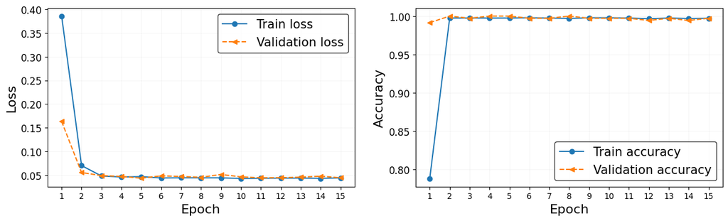

```python
x_arr = np.arange(len(base_info[0])) + 1
fig = plt.figure(figsize=(15, 4))
ax = fig.add_subplot(1, 2, 1)
ax.plot(x_arr, base_info[0], '-o', label='Train loss')
ax.plot(x_arr, base_info[2], '--<', label='Validation loss')
ax.legend(fontsize=15, frameon=True, edgecolor='k')
ax.set_xlabel('Epoch', size=16)
ax.set_ylabel('Loss', size=16)
ax.set_xticks(np.arange(len(base_info[0]))+1)
ax.tick_params(axis="x", labelsize=10)
ax.tick_params(axis="y", labelsize=12)
ax.grid(alpha=0.1)

ax = fig.add_subplot(1, 2, 2)
ax.plot(x_arr, base_info[1], '-o', label='Train accuracy')
ax.plot(x_arr, base_info[3], '--<', label='Validation accuracy')
ax.legend(fontsize=15, frameon=True, edgecolor='k')
ax.set_xlabel('Epoch', size=16)
ax.set_ylabel('Accuracy', size=16)
ax.set_xticks(np.arange(len(base_info[1]))+1)
ax.tick_params(axis="x", labelsize=10)
ax.tick_params(axis="y", labelsize=12)
ax.grid(alpha=0.1)

plt.show()
```

### Baseline Test Accuracy and Critical Temperature Estimate

The test accuracy achieved stands at 0.7225, which might not seem ideal initially. This suboptimal performance could be attributed to the small lattice sizes used in the experiment. In scenarios with small lattices, a very sharp transition at the critical temperature $T_c$ is often elusive. Consequently, configurations slightly above and below $T_c$ tend to appear similar, posing challenges for the model to make accurate predictions.

To estimate the critical temperature ($T_c$) on the test set ($2 < T < 2.5$), the following steps are performed:

- The predicted probabilities are averaged for each unique temperature.
- The results are then smoothed using linear interpolation.
- Finally, the temperature closest to a predicted probability of 0.5 is identified as $T_c$.

**This method resulted in a predicted $T_c$ = 2.2384. When compared to the standard $T_c$ of 2.269, the observed error is 1.35%**. This indicates that the baseline model has successfully fulfilled its predictive role, capturing the critical temperature with commendable accuracy.

```python
best_base_model = base_info[-1]
pred = best_base_model(X_test)[:, 0]
is_correct = ((pred >= 0.5).float() == y_test).int()
test_accuracy = (is_correct.sum() / is_correct.shape[0]).item()
print(f'Test set accuracy = {test_accuracy}')
```

```
Test set accuracy = 0.7225000262260437
```

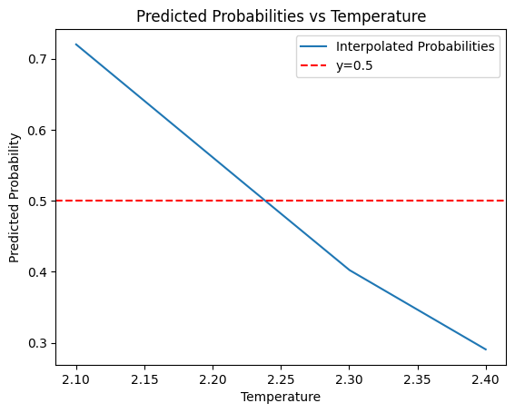

```
Estimated Tc = 2.2384
```

```python
from scipy.interpolate import interp1d

# Predict probabilities for each configuration in the test set
preds = best_base_model(X_test)[:, 0].detach().numpy()

# Compute the average predicted probability for each unique temperature in the test set
unique_temps = np.unique(T_test)
avg_probs = [np.mean(preds[T_test == temp]) for temp in unique_temps]

# Interpolate the average probabilities to get a smooth curve
f = interp1d(unique_temps, avg_probs, kind='linear')
temps_fine = np.linspace(min(unique_temps), max(unique_temps), 1000)
probs_fine = f(temps_fine)

# Find the temperature where the interpolated probability is closest to 0.5
estimated_Tc = temps_fine[np.argmin(np.abs(probs_fine - 0.5))]

plt.plot(temps_fine, probs_fine, label='Interpolated Probabilities')
plt.axhline(0.5, color='red', linestyle='--', label='y=0.5')
plt.xlabel('Temperature')
plt.ylabel('Predicted Probability')
plt.legend()
plt.title('Predicted Probabilities vs Temperature')
plt.show()

print(f'Estimated Tc = {estimated_Tc:.4f}')
```

## Hyperparameter tuning:

Following the training of the baseline model, the next pivotal step is hyperparameter tuning, for which the straightforward yet effective method of **Grid Search** is employed. Grid Search systematically explores a specified subset of the hyperparameter space, evaluating the performance of the model for each combination of parameters.

### Hyperparameter Space

**Units in Convolutional and Linear Layers** (Represented as tuples `(hd1, hd2, hd3)`): [(32, 64, 256), (32, 64, 128), ..., (32, 32, 64)]

- `hd1`: Number of filters in the first convolutional layer.
- `hd2`: Number of filters in the second convolutional layer.
- `hd3`: Number of neurons in the hidden linear layer.

**Weight Decay** (L2 Regularization): 0.001, 0.01, 0.1

**Dropout Probability**: 0.1, 0.2

**Learning Rate**: 0.001

### Tuning Procedure

1. **Setup**: Create `tuning_results_0p001` to store outcomes, and initialize `best_val_acc_0p001` and `best_params_0p001` for tracking the top performance.
2. **Iterate**: Loop through every combination of units, weight decay, and dropout.
3. **Train**: For each set, define the CNN, set up loss and optimizer, and run training via the `train` function.
4. **Evaluate**: Identify the maximum validation accuracy. Update `best_val_acc_0p001` and `best_params_0p001` if a new best is found.

```python
unit_vals = [(32, 64, 256), (32, 64, 128), (32, 64, 64), (32, 64, 32), (32, 64, 16), (32, 32, 128), (32, 32, 64)]
weight_decay_vals = [0.001, 0.01, 0.1]
dropout_vals = [0.1, 0.2]
lr = 0.001

tuning_results_0p001 = np.empty(shape=(7,3,2), dtype=object)
best_val_acc_0p001 = 0
best_params_0p001 = ((0,0,0), 0, 0)

u = 0

for unit in unit_vals:

    w = 0

    for weight_decay in weight_decay_vals:

        d = 0

        for dropout in dropout_vals:

            # print('\n')
            # print(f'units = {unit}, weight decay = {weight_decay}, dropout = {dropout}:  \n')

            hd1 = unit[0]
            hd2 = unit[1]
            hd3 = unit[2]

            model = nn.Sequential(

                nn.Conv2d(in_channels=1, out_channels=hd1, kernel_size=3, padding=1),
                nn.ReLU(),
                nn.MaxPool2d(kernel_size=2),
                nn.Conv2d(in_channels=hd1, out_channels=hd2, kernel_size=3, padding=1),
                nn.ReLU(),
                nn.MaxPool2d(kernel_size=2),
                nn.Flatten(),
                nn.Linear(3*3*hd2, hd3),
                nn.ReLU(),
                nn.Dropout(p=dropout),
                nn.Linear(hd3, 1),
                nn.Sigmoid()

            )

            loss_fn = nn.BCELoss()
            optimizer = torch.optim.Adam(model.parameters(), lr=lr, weight_decay=weight_decay)
            num_epochs = 50

            params = (unit, weight_decay, dropout)
            hist = train(model, num_epochs, train_dl, valid_dl)

            tuning_results_0p001[u, w, d] = [params, hist]

            val_acc = np.max(hist[3])
            if val_acc > best_val_acc_0p001:
                best_val_acc_0p001 = val_acc
                best_params_0p001 = params

            d += 1

        w += 1

    u += 1
```

```python
best_params_0p001
```

```
((32, 64, 256), 0.001, 0.1)
```

### Tunned Model Parameter

For our final model, let's use the hyperparameters which gave the best accuracy on our validation set as shown above. That is: $32$ filters for first Conv2d layer, $64$ filters for second Conv2d layer, $256$ units in hidden layer, $p=0.1$ dropout probability, and weight decay set to $0.001$.

```python
final_model = nn.Sequential(

    nn.Conv2d(in_channels=1, out_channels=32, kernel_size=3, padding=1),
    nn.ReLU(),
    nn.MaxPool2d(kernel_size=2),
    nn.Conv2d(in_channels=32, out_channels=64, kernel_size=3, padding=1),
    nn.ReLU(),
    nn.MaxPool2d(kernel_size=2),
    nn.Flatten(),
    nn.Linear(576, 256),
    nn.ReLU(),
    nn.Dropout(p=0.1),
    nn.Linear(256, 1),
    nn.Sigmoid()

)
```

```python
loss_fn = nn.BCELoss()
optimizer = torch.optim.Adam(final_model.parameters(), lr=0.001, weight_decay=0.001)
num_epochs = 50
```

```python
final_info = train(final_model, num_epochs, train_dl, valid_dl)
```

### Tunned Model test accuracy and Critical Temperature Estimate

Utilizing the same prediction methodology on the test dataset, **the tuned model yielded $T_c$ = 2.2628, with an error reduction to 0.28%**. This serves as substantial evidence that the CNN is capable of accurately predicting the critical temperature, even when high temperature and low temperature data are used for training.

```python
best_final_model = final_info[-1]
pred = best_final_model(X_test)[:, 0]
is_correct = ((pred >= 0.5).float() == y_test).int()
final_test_accuracy = (is_correct.sum() / is_correct.shape[0]).item()
print(f'Test set accuracy = {final_test_accuracy}')
```

```
Test set accuracy = 0.7300000190734863
```

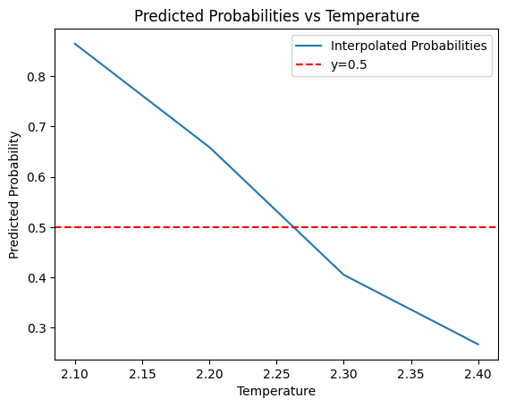

```
Estimated Tc = 2.2628
```

```python
preds = best_final_model(X_test)[:, 0].detach().numpy()

unique_temps = np.unique(T_test)
avg_probs = [np.mean(preds[T_test == temp]) for temp in unique_temps]

f = interp1d(unique_temps, avg_probs, kind='linear')
temps_fine = np.linspace(min(unique_temps), max(unique_temps), 1000)
probs_fine = f(temps_fine)

estimated_Tc = temps_fine[np.argmin(np.abs(probs_fine - 0.5))]

plt.plot(temps_fine, probs_fine, label='Interpolated Probabilities')
plt.axhline(0.5, color='red', linestyle='--', label='y=0.5')
plt.xlabel('Temperature')
plt.ylabel('Predicted Probability')
plt.legend()
plt.title('Predicted Probabilities vs Temperature')
plt.show()

print(f'Estimated Tc = {estimated_Tc:.4f}')
```